# 3 — Dimensionality reduction

Machine Learning (MPA-MLR)

Tomáš Vičar

Department of Biomedical Engineering · FEEC, Brno University of Technology

2026

## Curse of Dimensionality

[figure not shown]

With **4 bins per feature**, $d$ features give $4^d$ cells. For a fixed sample size $n$, the average occupancy is $n/4^d$.

$\rightarrow$ need more training data to fill this space

## Hughes Phenomenon

With *limited* training data, adding features can eventually **hurt prediction**: the information gained may not compensate for harder estimation.

[figure not shown]

**Key idea:** The best subset size depends on the **data and model**; an interior optimum is possible, not inevitable. Right: measured on synthetic data — 2 classes, 20 training samples, features added one by one (first 10 informative, the rest noise).

$\rightarrow$ reducing number of features can improve model! But which features to select?

## Feature Selection vs. Feature Reduction

**Feature selection** — choose a subset of original features

- **Filter methods** — model independent, statistical
  - Mutual information, correlation, mRMR
- **Wrapper methods** — use model performance
  - Forward selection, backward elimination
- **Embedded methods** — built into model training
  - LASSO / Elastic Net, decision trees, random forest

**Feature reduction (extraction)** — create new features from originals

- **Linear:** PCA, LDA
- **Non-linear:** t-SNE, UMAP, kernel PCA, autoencoders

**Key difference:** Selection keeps part of the original feature set; reduction builds new features.

## Filter methods

> Score features by statistical association, without fitting a predictor.

## Correlation Coefficients

**Pearson correlation**

- Measures **linear** dependence.
- Sensitive to outliers.
- Works with numeric variables, including discrete ones.
- $\rho_P \in [-1,1]$; 0 = no linear relation.

[figure not shown]

**Spearman correlation**

- Measures **monotonic** dependence.
- Uses ranks; less sensitive to extreme magnitudes.
- Works also for ordinal variables.
- $\rho_S \in [-1,1]$; 0 does not imply independence.

[figure not shown]

Use Pearson for linear association; Spearman for monotonic association or ordinal data.

## Pearson vs. Spearman Correlation

**Pearson = joint variation / scale normalization**
$$\rho_P(x,y)=\frac{\mathrm{cov}(x,y)}{\sigma_x\sigma_y}
=\frac{\sum_i(x_i-\bar x)(y_i-\bar y)}
{\sqrt{\sum_i(x_i-\bar x)^2\sum_i(y_i-\bar y)^2}}.$$

**Spearman = the same calculation on ranks**
$$\rho_S(x,y)=\rho_P(\mathrm{rank}(x),\mathrm{rank}(y)).$$

| Value | Interpretation | Typical example |
| --- | --- | --- |
| Near **+1** | Increase together | Height and weight |
| Near **−1** | One rises, the other falls | Temperature and heating costs |
| Near **0** | Little linear / monotonic association | Shoe size and exam score |

$\rho\in[-1,1]$. The sample factors $1/(n-1)$ cancel in the ratio.

## Pearson vs. Spearman by Hand

Five samples, $y$ doubles every step ($y = 2^{x-1}$):

| $x$ | $y$ | $x-\bar{x}$ | $y-\bar{y}$ | rank $x$ | rank $y$ |
| --- | --- | --- | --- | --- | --- |
| 1 | 1 | $-2$ | $-5.2$ | 1 | 1 |
| 2 | 2 | $-1$ | $-4.2$ | 2 | 2 |
| 3 | 4 | $0$ | $-2.2$ | 3 | 3 |
| 4 | 8 | $1$ | $1.8$ | 4 | 4 |
| 5 | 16 | $2$ | $9.8$ | 5 | 5 |

$\bar{x} = 3$, $\bar{y} = 6.2$; the $\tfrac{1}{n-1}$ factors cancel:
$$\rho_P = \frac{\sum (x_i-\bar{x})(y_i-\bar{y})}{\sqrt{\sum (x_i-\bar{x})^2\,\sum (y_i-\bar{y})^2}}$$
$$= \frac{36}{\sqrt{10 \cdot 148.8}} = \frac{36}{38.57} = 0.933$$

[figure not shown]

Ranks are identical $\Rightarrow$ $\rho_S = \rho_P(\mathrm{rank}\,x, \mathrm{rank}\,y) = 1$.

Perfectly monotonic, but not linear: Spearman says 1, Pearson only 0.93. Try it: swap the last two $y$ values — the ranks change, $\rho_S$ drops to $0.9$, $\rho_P$ to $0.73$.

## Entropy

**One variable: uncertainty of an outcome**
$$H(X)=-\sum_xp(x)\log_2p(x).$$

**Two variables: uncertainty of a pair**
$$H(X,Y)=-\sum_{x,y}p(x,y)\log_2p(x,y).$$

**After observing Y: remaining uncertainty of X**
$$H(X|Y)=-\sum_y p(y)\sum_xp(x|y)\log_2p(x|y).$$

**Examples in bits**

- Fair coin: **1**.
- Biased coin ($p=0.9$): **0.469**.
- Fair die: $\log_2 6=\mathbf{2.585}$.
- Certain outcome: **0**.

Estimate discrete probabilities by counting outcomes or pairs; histograms discretize continuous data. [code example](https://github.com/tomasvicar/MLR-public/blob/master/lectures/L3/code/entropy_example.py)

## Entropy histograms

[figure not shown]

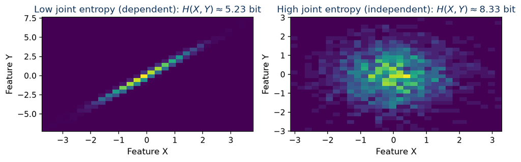

**Few occupied outcomes → less uncertainty; many evenly occupied outcomes → more.** Same 30 bins per axis; 1D range $[-3,3]$. Maxima: 4.91 bits (1D), 9.81 bits (2D).

## Mutual Information

**Information gained = uncertainty before − uncertainty after**
$$I(X;Y)=H(Y)-H(Y|X).$$

[figure not shown]

**Equivalent forms**
$$I(X;Y)=H(X)-H(X|Y)$$
$$=H(X)+H(Y)-H(X,Y).$$

**Discrete variables: from probabilities**
$$I(X;Y)=\sum_{x,y}p(x,y)\log_2\frac{p(x,y)}{p(x)p(y)}.$$

Captures nonlinear dependence and works with categorical variables too.

## Mutual Information in Practice

**Both variables discrete: count pairs**

1. Build a count table: $n_{xy}$ observations of each pair.
2. Divide by $n$; sum rows / columns for marginals:

$$\hat p(x,y)=\frac{n_{xy}}n,\qquad
\hat p(x)=\sum_y\hat p(x,y).$$

3. Substitute into the MI sum; skip zero-count cells.

**Continuous data: estimate local density**

- **kNN:** neighbour distances and counts measure local concentration; choose $k$.
- **KDE:** smooth bumps around samples estimate densities; choose bandwidth.
- **Binning:** discretize, then count pairs; bin edges and widths matter.

**Mixed pair:** use an estimator for continuous values within discrete groups.

**scikit-learn: choose by target type.** Class labels → `mutual_info_classif`; continuous target → `mutual_info_regression`. Mark input types with `discrete_features`.

scikit-learn returns **nats**; divide by $\ln 2$ for bits. [code example](https://github.com/tomasvicar/MLR-public/blob/master/lectures/L3/code/mutual_information_example.py)

## Correlation Matrix with Label

**Idea:** By adding the **label** to the correlation matrix we can see

- which features are strongly related to the target (**relevance**),
- which features are strongly related to each other (**redundancy**).

**Rows / columns:** $F_1,F_2,F_3,F_4,Y$.
$$\begin{bmatrix}
1.00 & 0.92 & 0.10 & -0.05 & 0.65 \\
0.92 & 1.00 & 0.08 & -0.12 & 0.60 \\
0.10 & 0.08 & 1.00 & 0.65 & 0.05 \\
-0.05 & -0.12 & 0.65 & 1.00 & 0.02 \\
0.65 & 0.60 & 0.05 & 0.02 & 1.00
\end{bmatrix}$$

[figure not shown]

**Selection rule: useful information, without duplication.**

- **Relevant:** $F_1$–$Y$: **0.65**; $F_2$–$Y$: **0.60**.
- **Redundant:** $F_1$–$F_2$: **0.92** — they largely overlap.

## mRMR: Minimum Redundancy, Maximum Relevance

- **Relevance:** information about the target.
- **Redundancy:** information already present in selected features.

Start with the feature having the largest $I(X_j;Y)$. For a nonempty selected set $\mathcal S$: **candidate relevance − average overlap**.

$$j^\star = \arg\max_{j\notin\mathcal S}
\left[\underbrace{I(X_j;Y)}_{\text{relevance}}
-\underbrace{\frac{1}{|\mathcal S|}\sum_{i\in\mathcal S} I(X_j;X_i)}_{\text{average redundancy}}\right].$$

Add $j^\star$ to $\mathcal S$ until the chosen budget $k$ is reached.

A **greedy filter**: use MI here, not the preceding correlation values; no predictor is fitted.

[code example](https://github.com/tomasvicar/MLR-public/blob/master/lectures/L3/code/mrmr_example.py)

## Wrapper methods

> Let the model itself say which subset of features works — at the price of training it many times over.

## Wrapper Selection Is Optimization

Choose a subset $S$ of the feature indices $\mathcal F=\{1,\ldots,d\}$:

$$S^\star = \arg\min_{\substack{S\subseteq\mathcal F\\ |S|=k}}
\underbrace{\hat R_{\mathrm{CV}}(\mathcal P_S)}_{\text{validation loss after fitting on features }S}$$

- **Decision:** which $k$ features to keep — a discrete search space.
- **One evaluation:** fit preprocessing + model inside each CV training fold.
- **As in the second lecture:** choose a pipeline; fit model parameters separately for each candidate.

Accuracy as the score? **Maximize** CV accuracy, equivalently minimize $1-\text{accuracy}$.

## One Objective, Different Search Strategies

| Strategy | Which subsets do we evaluate? | Trade-off |
| --- | --- | --- |
| **Brute force** | Every feasible subset | Best CV score; combinatorial cost |
| **Random search** | A budget of randomly sampled subsets | Broad exploration; no optimum guarantee |
| **Greedy heuristic** | All one-feature moves from the current subset | Cheap local steps; decisions are not revisited |

- **Forward:** start empty, repeatedly add the best candidate.
- **Backward:** start full, repeatedly remove the best candidate.

Same objective, different search paths — neither greedy direction guarantees the best subset. Definitions and worked example.

## Forward Selection: Steps, Trials and Evaluation

[figure not shown]

**Diagram:** stop on insufficient improvement; baseline = dummy predictor. **Next example:** stop at $k=2$.

## Forward Selection: Try Every Addition

[figure not shown]

**Greedy step:** $j^\star=\arg\max_{j\notin S}\mathrm{CVAcc}(S\cup\{j\})$, then $S\leftarrow S\cup\{j^\star\}$. **Stop here:** $|S|=2$. Added features stay selected.

Breast cancer data · logistic regression + scaling inside 5-fold CV · search scores, not test results. [code example](https://github.com/tomasvicar/MLR-public/blob/master/lectures/L3/code/forward_backward_example.py)

## Backward Elimination: Try Every Removal

[figure not shown]

**Greedy step:** $j^\star=\arg\max_{j\in S}\mathrm{CVAcc}(S\setminus\{j\})$, then $S\leftarrow S\setminus\{j^\star\}$. **Stop here:** $|S|=2$. Removed features cannot return.

Same data, model and CV splits · evaluate the remaining subset, not the removed feature alone. [code example](https://github.com/tomasvicar/MLR-public/blob/master/lectures/L3/code/forward_backward_example.py)

## Embedded Methods

> Some models pick their features while they are being fitted — and then we move from selecting features to building new ones.

## Embedded Methods

**Idea:** Feature selection happens **during model training** — the model itself decides which features are useful.

**Examples:**

- **Regularization:** LASSO (L1), Elastic Net
  - Can set coefficients exactly to zero.
- **Tree-based models:** decision trees, random forest, gradient boosted trees
  - Select features at splits; noise can also be selected.
- **Linear models with penalties:** SVM with L1 penalty, logistic regression with L1 or Elastic Net.

**Pros:** Selection is part of fitting; avoids a separate subset-search loop.

**Cons:** Model-specific; selected features may depend on model choice/hyperparameters.

Will be explained with individual models.

## Feature reduction

> Build a smaller set of new features from the original measurements.

## Feature Reduction – General View

**Goal:** Replace $d$ original features by $k \ll d$ new features, while preserving as much information as possible.

**In simple terms:** New features are created as a “mixture” of old features.

**General mapping:**
$$\mathbf{x} \in \mathbb{R}^d \;\;\mapsto\;\; \mathbf{z} \in \mathbb{R}^k$$

- **Linear reduction:** $\;\mathbf{z} = W^\top \mathbf{x}$, $\;W \in \mathbb{R}^{d \times k}$ — new features are weighted sums of the originals. *Examples: PCA, LDA, ICA*
- **Non-linear reduction:** $\;\mathbf{z} = f(\mathbf{x})$, $f$ is non-linear (NN, kernels, etc.) — can capture curved manifolds, local neighborhoods. *Examples: t-SNE, UMAP, autoencoders*

**Key trade-off:** linear = simple, interpretable; non-linear = more flexible, but less transparent.

## Linear reduction

> Use weighted sums of features to describe the data in fewer dimensions.

## Inner Product (Dot Product) and Projection

[figure not shown]

**Dot product (inner product):**
$$z = \mathbf{x}\cdot\mathbf{w} = \mathbf{x}^\top \mathbf{w}
= \langle \mathbf{x}, \mathbf{w} \rangle
= \|\mathbf{x}\|\,\|\mathbf{w}\|\,\cos\theta$$
If $\|\mathbf{w}\|=1$ (unit vector), then $z$ is the signed length of the projection of $\mathbf{x}$ onto $\mathbf{w}$.

**Matrix view (multiple directions):**
$$\mathbf{z} = W^\top \mathbf{x} \in \mathbb{R}^k,
\qquad
z_j = \mathbf{w}_j^\top \mathbf{x}$$
Each component $z_j$ is a dot product (projection) onto column $\mathbf{w}_j$ of $W$. It is also a linear transformation of the vector $\mathbf{x}$.

## Linearity Recap

**Linearity rules:**

- **Additivity:** $f(\mathbf{x}_1 + \mathbf{x}_2) = f(\mathbf{x}_1) + f(\mathbf{x}_2)$
- **Homogeneity:** $f(a \mathbf{x}) = a f(\mathbf{x})$
- $\rightarrow$ **Principle of superposition:** $f(a \mathbf{x}_1 + b \mathbf{x}_2) = a f(\mathbf{x}_1) + b f(\mathbf{x}_2)$, $\;\forall a,b \in \mathbb{R}$.

A linear function has to satisfy both rules — and the only functions that do are weighted sums of the inputs.

**Implication for linear reduction:** new features are **linear mixtures** (superpositions) of the originals.

**Example: one new feature $z_1$**
$$z_1 = w_{1,1} x_1 + w_{2,1} x_2 + \dots + w_{d,1} x_d,
\qquad
\text{e.g. } z_1 = 0.7 x_1 - 0.2 x_2 + 0.5 x_3$$
$x_j$ = original features; $w_{j,1}$ = weight of feature $x_j$ in the new feature $z_1$.

**Matrix form (all new features):** $\;\mathbf{z} = W^\top \mathbf{x}$, $\;W = [\mathbf{w}_1, \dots, \mathbf{w}_k]$

## Why Linearity is Useful

$$\mathbf z = W^\top\mathbf x$$

**Simple mathematics**

One matrix multiplication; standard linear algebra.

**Readable weights**

Each component is a weighted sum of the inputs.

**Clear geometry**

Rotations, scalings and projections; lines stay lines or collapse to points.

**Efficient computation**

Optimized matrix operations; PCA via eigenvectors or SVD.

**A useful starting point:** try a linear representation before adding complexity.

## Principal component analysis

> Find directions that preserve the most variance.

## Principal Component Analysis (PCA) – Introduction

**Unsupervised:** PCA learns from $X$ alone — no target labels required.

**Goal:** Project data onto fewer **uncorrelated components** that retain as much variance as possible.

**Intuition:**

- High-dimensional data often has redundant / correlated features.
- PCA finds new **axes (directions)** where the data varies the most.
- First PC = direction of maximum variance. Second PC = orthogonal to the first, with the next-largest variance, etc.

**Why use PCA?**

- Compress data with minimal squared reconstruction error.
- Denoise when discarded directions mainly contain noise.
- **Explore and visualize data:** 2D/3D views, trends and unusual samples.
- **Analyze feature relationships:** inspect component weights and biplots.
- **Preprocessing:** optional input to clustering or supervised models.

## Projection and Projection Error

**Setup:** Data points $\mathbf{x}_i \in \mathbb{R}^d$, $i=1,\dots,n$, are centered at the origin. We look for a unit direction $\mathbf{w}$ (a line through the origin).

**Projection of $\mathbf{x}_i$ on $\mathbf{w}$:**
$$z_i = \mathbf{w}^\top \mathbf{x}_i
\quad\Longrightarrow\quad
\hat{\mathbf{x}}_i = z_i\, \mathbf{w}$$
$z_i$ = coordinate of $\mathbf{x}_i$ along $\mathbf{w}$; $\hat{\mathbf{x}}_i$ = reconstructed point on the line.

**Projection (reconstruction) error:**
$$\mathbf{e}_i = \mathbf{x}_i - \hat{\mathbf{x}}_i,
\qquad \|\mathbf{e}_i\|^2 = \|\mathbf{x}_i\|^2 - z_i^2$$

[figure not shown]

**Why maximize the variance of projections?**

- Maximizing $\mathrm{Var}(z_i)$ $\Leftrightarrow$ minimizing the average reconstruction error $\|\mathbf{e}_i\|^2$.
- Intuition: choose the line where projected points are most “spread out” $\Leftrightarrow$ the line that yields the smallest projection error.

## Rotating the Direction: Variance vs. Error

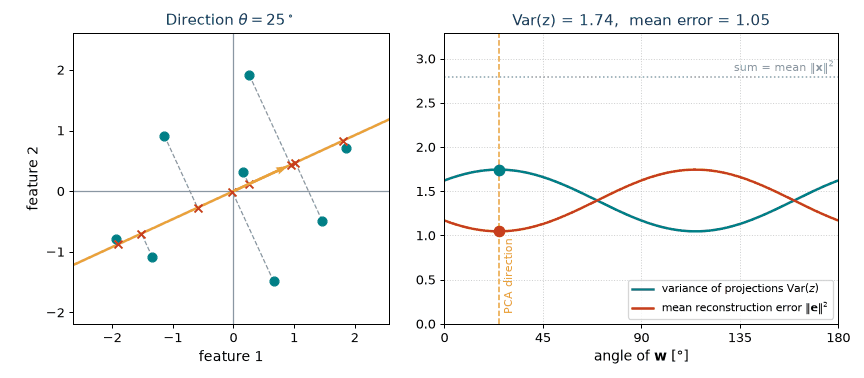

Same eight centered points, every direction $\mathbf{w}$ tried in turn. For every angle $\mathrm{Var}(z) + \tfrac{1}{n}\sum_i \|\mathbf{e}_i\|^2 = \tfrac{1}{n}\sum_i \|\mathbf{x}_i\|^2$ $\Rightarrow$ **largest variance** $\Leftrightarrow$ **smallest error**. The maximum $\mathrm{Var}(z) = 1.74$ is the largest eigenvalue of $S$ (next slides).

## From Projection Error to Variance Maximization

For centred inputs, a unit direction $\mathbf w$ and scores $z_i=\mathbf w^\top\mathbf x_i$:

$$\underbrace{\|\mathbf x_i\|^2}_{\text{original vector}}
=\underbrace{z_i^2}_{\text{projection}}
+\underbrace{\|\mathbf e_i\|^2}_{\text{reconstruction error}}.$$

Average over the samples:
$$\frac1n\sum_i\|\mathbf e_i\|^2
=\underbrace{\operatorname{trace}(S)}_{\text{total variance: fixed}}
-\underbrace{\mathbf w^\top S\mathbf w}_{\text{projected variance}},
\qquad S=\frac1nX^\top X.$$

**Minimum squared reconstruction error = maximum retained variance.**

## PCA as an Optimization Problem

**Setup (centered data):** Let $X \in \mathbb{R}^{n \times d}$ be zero-mean (each column centered). Empirical covariance (divisor $n$): $S = \tfrac{1}{n} X^\top X \in \mathbb{R}^{d \times d}$.

**First principal component (direction $\mathbf{w}_1$):**
$$\max_{\mathbf{w}_1 \in \mathbb{R}^d} \mathrm{Var}(X\mathbf{w}_1)
= \max_{\mathbf{w}_1} \mathbf{w}_1^\top S \mathbf{w}_1
\quad \text{s.t.}\quad \|\mathbf{w}_1\|_2 = 1 .$$

**Top-$k$ components (matrix $W \in \mathbb{R}^{d \times k}$):**
$$\max_{W \in \mathbb{R}^{d \times k}} \mathrm{trace}\big(W^\top S W\big)
\quad \text{s.t.}\quad W^\top W = I_k .$$

**Notes:**

- Orthonormality prevents repeated directions; **covariance eigenvectors** give uncorrelated scores.
- Centering $X$ is essential; otherwise $S$ mixes mean effects with variance.

## PCA Solution via Eigen-Decomposition

**Problem (recap):** $\;\max_{\mathbf{w}\in\mathbb{R}^d} \mathbf{w}^\top S \mathbf{w}\;$ s.t. $\|\mathbf{w}\|_2=1$.

How to solve it? We use a common optimization trick: put the constraint directly into the function we optimize (Lagrangian).

**Lagrangian:**
$$\mathcal{L}(\mathbf{w},\lambda) = \mathbf{w}^\top S \mathbf{w} - \lambda(\mathbf{w}^\top \mathbf{w}-1)$$

At a constrained optimum, the Lagrangian derivative is zero.

**Stationarity:**
$$\nabla_{\mathbf{w}}\mathcal{L}= 2S\mathbf{w} - 2\lambda \mathbf{w} = 0
\;\;\Longrightarrow\;\; S\mathbf{w}=\lambda\mathbf{w}$$

**Which eigenvector maximizes variance?** For a unit eigenvector:
$$\mathbf w^\top S\mathbf w=\lambda\mathbf w^\top\mathbf w=\lambda.$$
Choose the **largest eigenvalue**: it is the retained variance.

For top-$k$ components, the solution is just more eigenvectors with the largest eigenvalues.

## PCA by Hand: Four Points

**1. Centre and form the covariance** (column means are already $0$):
$$X = \begin{bmatrix} 2 & 1 \\ -2 & -1 \\ 1 & 2 \\ -1 & -2 \end{bmatrix},
\qquad
S = \tfrac{1}{4} X^\top X
= \tfrac{1}{4}\begin{bmatrix} 10 & 8 \\ 8 & 10 \end{bmatrix}
= \begin{bmatrix} 2.5 & 2 \\ 2 & 2.5 \end{bmatrix}$$

**2. Find directions and variances**

$\det(S - \lambda I) = (2.5-\lambda)^2 - 4 = 0$:
$$\lambda_1 = 4.5,\;\; \mathbf{w}_1 = \tfrac{1}{\sqrt{2}}\begin{bmatrix} 1 \\ 1 \end{bmatrix};
\qquad
\lambda_2 = 0.5,\;\; \mathbf{w}_2 = \tfrac{1}{\sqrt{2}}\begin{bmatrix} 1 \\ -1 \end{bmatrix}$$

**3. Project:** first score $(2+1)/\sqrt2=3/\sqrt2$.

$\mathbf{z}_1 = X\mathbf{w}_1 = \tfrac{1}{\sqrt 2}(3, -3, 3, -3)^\top = (2.12, -2.12, 2.12, -2.12)^\top$

**4. Check retained variance**

$\mathrm{Var}(z_1) = \tfrac{1}{4}\sum z_{1i}^2 = \tfrac{1}{4}\cdot 18 = 4.5 = \lambda_1$; explained variance $\lambda_1 / (\lambda_1+\lambda_2) = 90\,\%$.

[figure not shown]

## Using PCA: Exploration and Prediction

**PCA itself is unsupervised: its directions are fitted without labels.**

**Explore the data**

- Plot samples in **2D or 3D**.
- Look for trends, groups and unusual samples.
- Inspect **weights / biplots** to understand the axes.
- No prediction model is required.

**Prepare inputs for prediction**

1. Split data / set up CV.
2. Fit scaling + PCA on **training data only**.
3. Transform held-out data with that same fit.
4. Fit a predictor; tune $k$ inside CV.

**Different goals:** explained variance describes the data; validation scores assess prediction.

## Scree plot and Biplot

**Unsupervised exploration of Iris:** standardized features; labels only colour the points.

[figure not shown]

## Linear discriminant analysis

> Use labels to find directions that separate classes.

## PCA vs. LDA

[figure not shown]

- Both are **linear** projections: $Z = XW$ (to a line here; in general to a $k$-D subspace).
- **PCA** is *unsupervised*: ignores labels and **maximizes variance** (equivalently, *minimizes reconstruction error*).
- **LDA** is *supervised*: uses labels and **maximizes class separation** (between-class $\uparrow$, within-class $\downarrow$).

## LDA: Class Means and Within-Class Spread

[figure not shown]

- **Diamonds:** the mean projected position of each class.
- **Bars:** mean ± one standard deviation; **variance** is the average squared distance from that class mean.
- **LDA:** separate the class means while keeping within-class spread small.

## Linear Discriminant Analysis (LDA) — Idea

**Compute a separating direction**

1. **Class means** $\boldsymbol\mu_c$.
2. **Within-class scatter** $S_W$.
3. Two classes: **maximize Fisher’s criterion**

$$\max_{\mathbf w}\;
\frac{\big(\mathbf w^\top(\boldsymbol\mu_1-\boldsymbol\mu_2)\big)^2}
{\mathbf w^\top S_W\,\mathbf w}
\;\;
\begin{array}{l}
\scriptstyle\leftarrow\,\text{separation}\uparrow\\[6pt]
\scriptstyle\leftarrow\,\text{spread}\downarrow
\end{array}$$

Optimum: solve $S_W\mathbf w=\boldsymbol\mu_1-\boldsymbol\mu_2$.  
Score: $z=\mathbf w^\top\mathbf x$.

**Used in practice**

- **Classifier:** practical use, e.g. regularized LDA for EEG signals.
- **Supervised projection:** separates known classes; needs labels.
- **For $C$ classes:** at most $\min(d,C-1)$ directions; not a general replacement for PCA.

For two classes, **one score + a threshold** gives a linear classifier.

Singular $S_W$: use regularization or a rank-aware solver. Derivation and example · [EEG application](https://pubmed.ncbi.nlm.nih.gov/20600976/)

## Nonlinear reduction

> Preserve local neighbourhoods when a linear projection is not enough.

## t-SNE: Keep Neighbours Close

1. **In the original space:** assign stronger similarity to nearby samples.
2. **On a 2D map:** move points so these neighbourhoods are reproduced.
3. **Balance attraction and repulsion:** neighbours gather without everything collapsing.
- **`perplexity`:** effective neighbourhood size; smaller values focus more locally.
- **`learning_rate`:** size of optimization steps; `init` and `random_state` affect the layout.

Read **local neighbourhoods**. Gaps, island sizes and inter-island distances are not calibrated measurements.

## UMAP: Build a Neighbour Graph, Then Lay It Out

**Learn the representation**

1. Find neighbours in the input space.
2. Build a **weighted neighbour graph**.
3. Embed it in fewer dimensions, preserving strong connections.

**Choose the settings**

- **`n_neighbors`:** neighbourhood scale.
- **`min_dist`:** output packing.
- **`metric`:** input distance.
- **`n_components`:** output dimension; not limited to 2D.

**UMAP has `transform`; scikit-learn t-SNE does not.**

**UMAP before a classifier:** `fit_transform(X_train)` → fit classifier; `transform(X_new)` → predict with the same classifier.

Extensions such as openTSNE also offer new-sample placement. [UMAP: transforming new data](https://umap-learn.readthedocs.io/en/latest/transform.html)

## PCA, t-SNE and UMAP: the Same Digits

[figure not shown]

**Same samples and preprocessing; labels only colour the plot.** PCA preserves variance; t-SNE and UMAP emphasize neighbourhood structure.

Separate axis scales. Clear islands alone do not establish classes, cluster density or predictive accuracy. [code example](https://github.com/tomasvicar/MLR-public/blob/master/lectures/L3/code/tsne_umap_example.py)

## t-SNE: the Same Data, Four Perplexities

[figure not shown]

`perplexity` ≈ effective number of neighbours each point “cares about” (often explored around 5–50). Smaller values emphasize local detail; larger values connect broader neighbourhoods. The useful scale depends on the data. **The layout is not a property of the data alone:** always state the hyperparameters with a t-SNE figure.

## Other Reduction Methods

- **Kernel PCA**
- **Isomap**
- **NMF — Nonnegative Matrix Factorization**
- **Factor Analysis**
- **Autoencoders**

Short method summaries in the appendix. Next: the essential idea behind kernels.

## Feature expansion and kernels

> Explore a richer feature space before finding a compact representation.

## Feature Expansion (Higher Dimension)

[figure not shown]

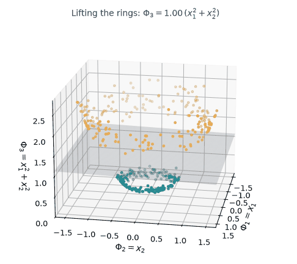

**The map in this animation:** $\Phi_{\mathrm{rings}}(x_1,x_2)=(x_1,x_2,x_1^2+x_2^2)$ — add squared radius.

**Other explicit expansions:** polynomial features $\Phi(x_1,x_2) = (x_1,\, x_2,\, x_1^2,\, x_1x_2,\, x_2^2,\, \dots)$

**Implicit expansion (kernels):** use the kernel trick — inner product in a high-$D$ space without computing $\Phi(\mathbf{x})$ explicitly.

**Takeaway:** Feature *expansion* increases dimensionality to make data more linearly separable (effectively you get a non-linear method from a linear one). Logistic regression on the rings: accuracy 0.55 in 2D, 1.00 after $\Phi_{\mathrm{rings}}$. · [code example](https://github.com/tomasvicar/MLR-public/blob/master/lectures/L3/code/feature_expansion_example.py)

## Kernels: Compare Without Expanding

- **Explicit expansion:** construct new features, then take a dot product.
- **Kernel trick:** compute that dot product **without constructing the features**.

$$k(\mathbf{x},\mathbf{z})=\Phi(\mathbf{x})^\top\Phi(\mathbf{z})$$

A small example: $k(\mathbf{x},\mathbf{z})=(\mathbf{x}^\top\mathbf{z})^2$ corresponds to quadratic features. For many samples, collect pairwise kernel values in a **Gram matrix** $K$.

**Fourth lecture:** kernel functions, the dual formulation, kernel regression and SVMs. Optional algebra and kernel PCA.

## Kernel Trick example

**A different quadratic map:** two equivalent ways to compute its dot product.

**1. Explicit feature expansion:**
$$\Phi(\mathbf{x}) = (x_1^2, \; x_2^2, \; \sqrt{2}\,x_1 x_2)$$
$$\Phi(\mathbf{x}_i)^\top \Phi(\mathbf{x}_j)
= x_{i1}^2 x_{j1}^2 + x_{i2}^2 x_{j2}^2 + 2 x_{i1} x_{i2} x_{j1} x_{j2}$$

**2. Direct computation (kernel trick):**
$$(\mathbf{x}_i^\top \mathbf{x}_j)^2
= (x_{i1} x_{j1} + x_{i2} x_{j2})^2
= x_{i1}^2 x_{j1}^2 + x_{i2}^2 x_{j2}^2 + 2 x_{i1} x_{i2} x_{j1} x_{j2}$$

**Conclusion:** Computing $\Phi(\mathbf{x}_i)^\top \Phi(\mathbf{x}_j)$ explicitly is the same as computing $(\mathbf{x}_i^\top \mathbf{x}_j)^2$. $\Rightarrow$ the kernel function avoids the explicit high-dimensional mapping.

## Kernel PCA: PCA in a Nonlinear Feature Space

**Conceptually:** transform the inputs, then apply ordinary PCA there.
$$\underbrace{\mathbf x}_{d}\ \xrightarrow{\ \Phi\ }\ \underbrace{\Phi(\mathbf x)}_{D}
\xrightarrow{\ \text{linear PCA}\ }\ \underbrace{\mathbf z}_{k}.$$

**With the kernel trick:**

1. Compute pairwise inner products $K_{ij}=k(\mathbf x_i,\mathbf x_j)$.
2. **Centre the Gram matrix** to centre the implicit feature space.
3. Use its leading eigenvectors and eigenvalues to obtain component scores.

**Linear in the feature space, nonlinear in the original inputs.** The kernel determines which structure PCA can capture.

Unsupervised; fitted kernel PCA can transform new samples. Detailed algebra · [code example](https://github.com/tomasvicar/MLR-public/blob/master/lectures/L3/code/kernel_pca_example.py)

## Take-Home Messages

- **Selection:** keep original variables; filters, wrappers and embedded methods differ in how they choose.
- **PCA:** preserve variance with linear projections; choose scaling deliberately.
- **LDA:** use labels to find separating directions.
- **t-SNE / UMAP:** represent neighbourhoods; UMAP also transforms new samples before prediction.
- **Kernels:** implicit feature expansion — continued in the fourth lecture.

## Recap Quiz

- Why can individually **relevant** features still be **redundant**?
- Why is trying every next addition **not exhaustive** subset search?
- What does **PCA optimize**, and what distinction can **LDA** retain that PCA loses?
- Which fitted methods can process **new samples**, and what does the **kernel trick** avoid computing?

## Appendix: Three Search Strategies

**Same task:** choose a feature subset with the lowest validation loss.

**Exhaustive / brute force**

Evaluate **every** feasible subset.

Best score guaranteed.

Cost grows quickly.

**Greedy**

Take the **best next step**.

Commit to one path.

No global guarantee.

**Random search**

Sample **complete subsets** at random.

Set a trial budget.

No global guarantee.

**Grid search** is exhaustive search over a chosen parameter grid. Example: 3 values of $C$ × 2 values of $\gamma$ = **6 combinations**.

## One Example: Greedy Can Miss the Best Pair

[figure not shown]

- **Greedy:** best single feature $A$ → best pair containing it $AB$ → loss **0.18**.
- **Brute force:** checks all three pairs → $BC$ → loss **0.10**.
- **Random search:** can find $BC$ if that pair is sampled.

Constructed example: choose exactly two features. Lower loss is better.

## Heuristics: Practical Rules for Searching

A **heuristic** guides the search without a general global-optimality guarantee. **Greedy selection is one example.**

**Local search**

Start with a complete subset. **Swap one feature:** $AB\to BC$, replacing $A$ with $C$. Loss **0.18 → 0.10**. Keep an improving move.

**Random restarts**

Repeat local search from different starting subsets. Keep the best result.

**Small search space:** brute force. **Limited budget:** compare greedy, random or local search under the same budget.

## Appendix: LDA Details

> Optional Fisher criterion and projection algebra.

## LDA (Fisher) — Binary case in one slide

**Goal:** Find a direction $\mathbf{w}$ so that the two classes are *far apart after projection* $z=\mathbf{w}^\top\mathbf{x}$ but each class is *tight*.

**After projection:**
$$\tilde{\mu}_c = \mathbf{w}^\top \boldsymbol{\mu}_c
\qquad\text{(projected class mean)}$$
$$\tilde{s}_c^{\,2} = \mathbf{w}^\top S_c\,\mathbf{w},
\quad
S_c=\!\!\sum_{i:\,y_i=c}(\mathbf{x}_i-\boldsymbol{\mu}_c)(\mathbf{x}_i-\boldsymbol{\mu}_c)^\top
\qquad\text{(projected within-class scatter)}$$

**Scatter = sum of squared deviations:** $\tilde s_c^2=n_c\operatorname{Var}_c(z)$ (divisor $n_c$).

**Fisher criterion (maximize separation / penalize spread):**
$$J(\mathbf{w}) =
\frac{(\tilde{\mu}_1-\tilde{\mu}_2)^2}{\tilde{s}_1^{\,2}+\tilde{s}_2^{\,2}}
=
\frac{\big(\mathbf{w}^\top(\boldsymbol{\mu}_1-\boldsymbol{\mu}_2)\big)^2}
{\mathbf{w}^\top S_W \mathbf{w}},
\qquad S_W=S_1+S_2 .$$

**Optimum:** $\nabla J=0$ gives $S_W\mathbf w\propto\boldsymbol\mu_1-\boldsymbol\mu_2$ (the factors $\mathbf w^\top(\boldsymbol\mu_1-\boldsymbol\mu_2)$ and $\mathbf w^\top S_W\mathbf w$ are scalars). For nonsingular $S_W$, one optimal direction (up to nonzero scale) is:
$$\boxed{\;\mathbf{w} = S_W^{-1}(\boldsymbol{\mu}_1-\boldsymbol{\mu}_2)\;}$$
For the multi-class case this leads to an eigenvalue problem: $S_W^{-1} S_B\,\mathbf{w} = \lambda\,\mathbf{w}$.

## Appendix: t-SNE and UMAP Details

> From input distances to pairwise relationships, optimized coordinates and new-sample placement.

## t-SNE: Turn Distances into Probabilities

**Input relationships:** $\mathbf x_i\in\mathbb R^d$; map $\mathbf z_i\in\mathbb R^m$, usually $m=2$.

$$p_{j\mid i}=\frac{\exp\!\left(-\|\mathbf x_i-\mathbf x_j\|^2/(2\sigma_i^2)\right)}
{\sum_{\ell\ne i}\exp\!\left(-\|\mathbf x_i-\mathbf x_\ell\|^2/(2\sigma_i^2)\right)},
\qquad p_{i\mid i}=0.$$

- **Perplexity example:** four equally likely neighbours → 2 bits → perplexity 4.
- **Local scale:** choose each $\sigma_i$ to match the requested perplexity.

$$\operatorname{Perp}(P_i)=2^{H(P_i)},\qquad
H(P_i)=-\sum_{j\ne i}p_{j\mid i}\log_2 p_{j\mid i}.$$

Symmetrize: $\displaystyle p_{ij}=\frac{p_{j\mid i}+p_{i\mid j}}{2n}$, **probabilities sum to one:** $\sum_{i\ne j}p_{ij}=1$.

## t-SNE: Match Probabilities in the Map

**Map relationships:** a heavy-tailed similarity, normalized over pairs:
$$q_{ij}=\frac{(1+\|\mathbf z_i-\mathbf z_j\|^2)^{-1}}
{\sum_{a\ne b}(1+\|\mathbf z_a-\mathbf z_b\|^2)^{-1}},
\qquad q_{ii}=0.$$

**Mismatch to minimize:** optimize coordinates with $P$ fixed:
$$\min_{\mathbf z_1,\ldots,\mathbf z_n}
\mathcal L=\operatorname{KL}(P\|Q)
=\sum_{i\ne j}p_{ij}\log\frac{p_{ij}}{q_{ij}}.$$

- **Large $p_{ij}$, tiny $q_{ij}$:** input neighbours are separated too far.
- **Heavy tails:** moderate similarities can be represented at larger map distances.
- **Goal:** match neighbourhood probabilities, not original distances.

[Original t-SNE paper](https://www.jmlr.org/papers/v9/vandermaaten08a.html)

## t-SNE: What Actually Moves the Points?

**Update:** the gradient of the exact objective above:
$$\nabla_{\mathbf z_i}\mathcal L
=4\sum_{j\ne i}(p_{ij}-q_{ij})
\frac{\mathbf z_i-\mathbf z_j}{1+\|\mathbf z_i-\mathbf z_j\|^2}.$$

A gradient step moves **against** this vector: $\mathbf z_i\leftarrow\mathbf z_i-\eta\nabla_{\mathbf z_i}\mathcal L$.

- **$p_{ij}>q_{ij}$:** this pair contributes attraction.
- **$p_{ij}<q_{ij}$:** this pair contributes repulsion.
- **Nonconvex:** initialization and optimization settings affect the layout.

The point follows the **sum of all pair contributions**; no individual pair controls its motion.

## UMAP: Build a Locally Scaled Graph

**Input relationships:** $d_{ij}$ is the distance to a retained neighbour $j$:
$$a_{j\mid i}=\exp\!\left(-\frac{\max(0,d_{ij}-\rho_i)}{\sigma_i}\right).$$

- **$\rho_i$:** local distance offset; the nearest connections get full strength.
- **$\sigma_i$:** local scale, adjusted to the chosen neighbourhood size.
- **Outside the neighbour list:** set the directed weight to zero.

**Combine directed strengths:** fuzzy union; $0.8+0.5-0.8\cdot0.5=0.9$.
$$v_{ij}=a_{j\mid i}+a_{i\mid j}-a_{j\mid i}a_{i\mid j}.$$

$v_{ij}\in[0,1]$ is an **edge membership strength**. Unlike t-SNE’s $p_{ij}$, these weights do not sum to one.

## UMAP: Fit a Low-Dimensional Graph

**Map relationships:** for output coordinates $\mathbf z_i$, define
$$q_{ij}=\frac{1}{1+a\|\mathbf z_i-\mathbf z_j\|^{2b}},\qquad a,b>0.$$

**Mismatch to minimize:** graph cross-entropy (constant terms omitted):
$$\mathcal L_{\mathrm{graph}}=-\sum_{i<j}\left[
v_{ij}\log q_{ij}+(1-v_{ij})\log(1-q_{ij})\right].$$

- **Strong edges:** attraction favours larger $q_{ij}$, hence smaller distances.
- **Weak / absent edges:** repulsion discourages collapsing all points together.
- **`min_dist`, `spread`:** determine the curve parameters $a,b$.

Practical UMAP samples attractive edges and negative pairs; this changes their effective weighting. [Paper](https://arxiv.org/abs/1802.03426) · [Sampling and the effective loss](https://arxiv.org/abs/2103.14608)

## UMAP: How New Samples Enter the Map

Keep the fitted training embedding $Z_{\mathrm{train}}$ fixed.

1. **Find neighbours** of $\mathbf x_{\mathrm{new}}$ among training samples.
2. **Compute connection strengths** to those reference neighbours.
3. **Initialize** near a weighted combination of their map coordinates.
4. **Optimize the new coordinates** against the fixed reference embedding.

The same fitted representation supports **training a classifier and later prediction**. Use `n_components` for the task; it need not be 2.

[UMAP transform](https://umap-learn.readthedocs.io/en/latest/transform.html) · scikit-learn t-SNE lacks `transform`; openTSNE offers placement in a reference map.

## Appendix: Other Reduction Methods

> Different objectives preserve different aspects of the data.

## Isomap: Follow Distances Along the Surface

1. Connect **nearby samples** in a weighted neighbour graph.
2. Approximate distances along the surface by **shortest paths**.
3. Find low-dimensional coordinates that reproduce those distances.

$$\|\mathbf z_i-\mathbf z_j\|\ \approx\ d_{\mathrm{graph}}(i,j).$$

On a rolled sheet, travel **along the sheet**, not straight across its folds.

## NMF: Build Samples from Nonnegative Parts

For nonnegative data $X\in\mathbb R^{n\times d}$, choose $k<d$:

$$X\approx ZH,\qquad
\min_{Z,H\ge0}\|X-ZH\|_F^2.$$

- **$H$:** $k$ component patterns, each with $d$ features.
- **$Z$:** $k$ nonnegative weights for each sample — the reduced representation.
- **Additive:** combine patterns without subtracting one from another.

## Factor Analysis: Shared Factors and Separate Noise

Model each observation as
$$\mathbf x=\boldsymbol\mu+W\mathbf z+\boldsymbol\epsilon,
\qquad \mathbf z\in\mathbb R^k,\quad k<d.$$

- **$\mathbf z$:** a few latent factors shared across features.
- **$W$:** loadings describing how each factor affects each feature.
- **$\boldsymbol\epsilon$:** feature-specific noise; each feature has its own variance.

Explain **shared variation** separately from **feature-specific noise**.

## Autoencoder: Learn to Compress and Reconstruct

$$\mathbf x\ \xrightarrow{\ \text{encoder }f_\theta\ }
\mathbf z\in\mathbb R^k
\ \xrightarrow{\ \text{decoder }g_\phi\ }
\hat{\mathbf x},\qquad k<d.$$

- **Encoder:** learns the reduced representation $\mathbf z$.
- **Decoder:** reconstructs the input from that representation.
- **Train both:** minimize reconstruction loss, for example

$$\min_{\theta,\phi}\frac1n\sum_i
\|\mathbf x_i-g_\phi(f_\theta(\mathbf x_i))\|^2.$$

## Appendix: Kernels and Kernel PCA

> Optional algebra; the fourth lecture develops kernels for prediction.

## Kernel Trick by Hand: The Same Result

Use $\mathbf x=(1,2)^\top$, $\mathbf u=(3,4)^\top$ and
$$\Phi(\mathbf x)=(x_1^2,\ x_2^2,\ \sqrt2\,x_1x_2)^\top.$$

**Explicit transformation: 2D → 3D**

$$\Phi(\mathbf x)=(1,4,2\sqrt2)^\top$$
$$\Phi(\mathbf u)=(9,16,12\sqrt2)^\top$$
$$\Phi(\mathbf x)^\top\Phi(\mathbf u)
=9+64+48=\boxed{121}.$$

**Kernel: stay with the 2D inputs**

$$k(\mathbf x,\mathbf u)=(\mathbf x^\top\mathbf u)^2$$
$$=(1\cdot3+2\cdot4)^2$$
$$=11^2=\boxed{121}.$$

**Same inner product, without constructing the expanded vectors.** The factor $\sqrt2$ makes the cross term match.

## PCA: Primal vs. Dual

Same PCA scores, from matrices of different sizes. $X$ contains centred training rows.

**Primal: a $d\times d$ matrix**

$$S=\frac1nX^\top X,\qquad
S\mathbf w_k=\lambda_k\mathbf w_k.$$

Project a centred new sample:
$$t_k=\mathbf x_{\mathrm{new}}^\top\mathbf w_k.$$

**Dual: an $n\times n$ matrix**

$$S'=XX^\top,\qquad
S'\boldsymbol\alpha_k=n\lambda_k\boldsymbol\alpha_k.$$
$$\mathbf w_k=\frac{X^\top\boldsymbol\alpha_k}{\sqrt{n\lambda_k}},
\qquad \lambda_k>0.$$
$$t_k=\frac{\sum_i\alpha_{ik}\,\mathbf x_{\mathrm{new}}^\top\mathbf x_i}
{\sqrt{n\lambda_k}}.$$

Use **unit eigenvectors** and the **training mean** for centring. The smaller matrix depends on whether $d<n$ or $n<d$.

## Kernel PCA

**Fit:** compute $K_{ij}=k(\mathbf x_i,\mathbf x_j)$ and centre it:
$$\tilde K=HKH,\qquad H=I-\tfrac1n\mathbf1\mathbf1^\top,
\qquad \tilde K\boldsymbol\alpha_k=n\lambda_k\boldsymbol\alpha_k.$$
Use unit eigenvectors $\boldsymbol\alpha_k$ with $\lambda_k>0$; $\mathbf1$ is the vector of $n$ ones.

**Transform a new sample:** first centre its kernel values using the training data:
$$\begin{aligned}
\tilde k(\mathbf x,\mathbf x_i)
&=\underbrace{k(\mathbf x,\mathbf x_i)}_{\text{raw similarity}}
-\underbrace{\frac1n\sum_j k(\mathbf x,\mathbf x_j)}_{\text{new-to-training mean}}\\
&\quad-\underbrace{\frac1n\sum_j K_{ji}}_{\text{training column mean: stored}}
+\underbrace{\frac1{n^2}\sum_{j,\ell}K_{j\ell}}_{\text{training grand mean: stored}}.
\end{aligned}$$
Then project:
$$t_k=\frac1{\sqrt{n\lambda_k}}\sum_i\alpha_{ik}\,\tilde k(\mathbf x,\mathbf x_i).$$

Transform uses the **fitted training reference**, without explicitly computing the feature space. [code example](https://github.com/tomasvicar/MLR-public/blob/master/lectures/L3/code/kernel_pca_example.py)